# Project: Investigate a Dataset (Replace this with something more specific!)

## Exploratory Data Analysis

> **Tip**: Now that you've trimmed and cleaned your data, you're ready to move on to exploration. Compute statistics and create visualizations with the goal of addressing the research questions that you posed in the Introduction section. It is recommended that you be systematic with your approach. Look at one variable at a time, and then follow it up by looking at relationships between variables.

### Profit in each movie:

```python
if 'Profit' in tmdb_data:
    delete = ['Profit']
    tmdb_data = tmdb_data.drop(delete,1)

profit = tmdb_data['revenue'] - tmdb_data['budget']
tmdb_data.insert(2,'Profit', profit)
tmdb_data.head(4)
```

|  | popularity | budget | Profit | revenue | original_title | cast | director | tagline | overview | runtime | genres | release_date | vote_average | release_year | budget_adj | revenue_adj |
| --- | --- | --- | --- | --- | --- | --- | --- | --- | --- | --- | --- | --- | --- | --- | --- | --- |
| 0 | 32.985763 | 150000000.0 | 1.363529e+09 | 1.513529e+09 | Jurassic World | Chris Pratt\|Bryce Dallas Howard\|Irrfan Khan\|Vi... | Colin Trevorrow | The park is open. | Twenty-two years after the events of Jurassic ... | 124 | Action\|Adventure\|Science Fiction\|Thriller | 2015-06-09 | 6.5 | 2015 | 1.379999e+08 | 1.392446e+09 |
| 1 | 28.419936 | 150000000.0 | 2.284364e+08 | 3.784364e+08 | Mad Max: Fury Road | Tom Hardy\|Charlize Theron\|Hugh Keays-Byrne\|Nic... | George Miller | What a Lovely Day. | An apocalyptic story set in the furthest reach... | 120 | Action\|Adventure\|Science Fiction\|Thriller | 2015-05-13 | 7.1 | 2015 | 1.379999e+08 | 3.481613e+08 |
| 2 | 13.112507 | 110000000.0 | 1.852382e+08 | 2.952382e+08 | Insurgent | Shailene Woodley\|Theo James\|Kate Winslet\|Ansel... | Robert Schwentke | One Choice Can Destroy You | Beatrice Prior must confront her inner demons ... | 119 | Adventure\|Science Fiction\|Thriller | 2015-03-18 | 6.3 | 2015 | 1.012000e+08 | 2.716190e+08 |
| 3 | 11.173104 | 200000000.0 | 1.868178e+09 | 2.068178e+09 | Star Wars: The Force Awakens | Harrison Ford\|Mark Hamill\|Carrie Fisher\|Adam D... | J.J. Abrams | Every generation has a story. | Thirty years after defeating the Galactic Empi... | 136 | Action\|Adventure\|Science Fiction\|Fantasy | 2015-12-15 | 7.5 | 2015 | 1.839999e+08 | 1.902723e+09 |

### Research Question 1) Which movie has made the maximum and minimum profit?

```python
# Use this, and more code cells, to explore your data. Don't forget to add
#   Markdown cells to document your observations and findings.
import pprint

def profit(column):
    maximum = tmdb_data[column].idxmax()
    details = pd.DataFrame(tmdb_data.loc[maximum])

    minimum = tmdb_data[column].idxmin()
    detail = pd.DataFrame(tmdb_data.loc[minimum])

    result = pd.concat([details, detail], axis = 1)

    return result

profit('Profit')
```

|  | 1386 | 2244 |
| --- | --- | --- |
| popularity | 9.43277 | 0.25054 |
| budget | 2.37e+08 | 4.25e+08 |
| Profit | 2.54451e+09 | -4.13912e+08 |
| revenue | 2.78151e+09 | 1.10876e+07 |
| original_title | Avatar | The Warrior's Way |
| cast | Sam Worthington\|Zoe Saldana\|Sigourney Weaver\|S... | Kate Bosworth\|Jang Dong-gun\|Geoffrey Rush\|Dann... |
| director | James Cameron | Sngmoo Lee |
| tagline | Enter the World of Pandora. | Assassin. Hero. Legend. |
| overview | In the 22nd century, a paraplegic Marine is di... | An Asian assassin (Dong-gun Jang) is forced to... |
| runtime | 162 | 100 |
| genres | Action\|Adventure\|Fantasy\|Science Fiction | Adventure\|Fantasy\|Action\|Western\|Thriller |
| release_date | 2009-12-10 00:00:00 | 2010-12-02 00:00:00 |
| vote_average | 7.1 | 6.4 |
| release_year | 2009 | 2010 |
| budget_adj | 2.40887e+08 | 4.25e+08 |
| revenue_adj | 2.82712e+09 | 1.10876e+07 |

### Research Question 2) What is the business(profit) each year?

### Represent it with a chart

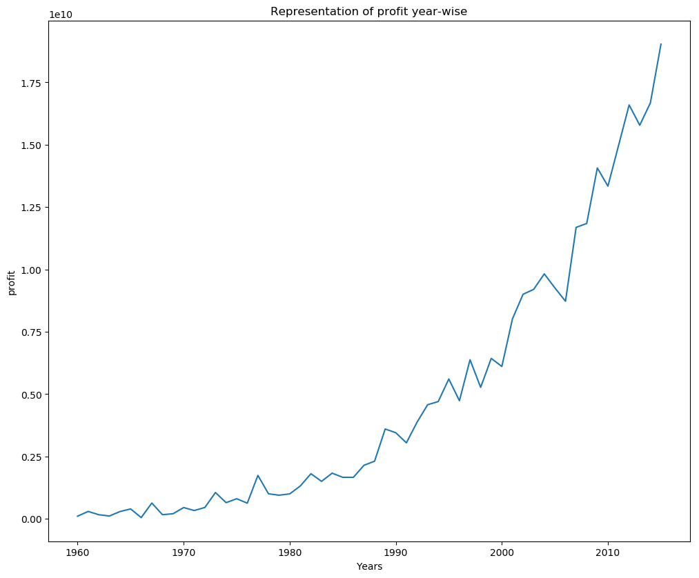

```python
profit = tmdb_data.groupby('release_year')['Profit'].sum()
plt.figure(figsize = (12,10), dpi = 100)
plt.title('Representation of profit year-wise')
plt.plot(profit)
plt.xlabel('Years')
plt.ylabel('profit')
plt.show()
```

##### Year with maximum profit

```python
profit.idxmax()
```

```
2015
```

### Research Question 3) Which movie has maximum and minimum runtime value?

```python
# Continue to explore the data to address your additional research
#   questions. Add more headers as needed if you have more questions to
#   investigate.
import pprint

def compute(column):
    maximum = tmdb_data[column].idxmax()
    details = pd.DataFrame(tmdb_data.loc[maximum])

    minimum = tmdb_data[column].idxmin()
    detail = pd.DataFrame(tmdb_data.loc[minimum])

    result = pd.concat([details, detail], axis = 1)

    return result

compute('runtime')
```

|  | 2107 | 5162 |
| --- | --- | --- |
| popularity | 0.534192 | 0.208637 |
| budget | 1.8e+07 | 10 |
| Profit | -1.71287e+07 | -5 |
| revenue | 871279 | 5 |
| original_title | Carlos | Kid's Story |
| cast | Edgar RamÃrez\|Alexander Scheer\|Fadi Abi Samra... | Clayton Watson\|Keanu Reeves\|Carrie-Anne Moss\|K... |
| director | Olivier Assayas | Shinichiro Watanabe |
| tagline | The man who hijacked the world | NaN |
| overview | The story of Venezuelan revolutionary, Ilich R... | A high school student is haunted by thoughts o... |
| runtime | 338 | 15 |
| genres | Crime\|Drama\|Thriller\|History | Science Fiction\|Animation |
| release_date | 2010-05-19 00:00:00 | 2003-06-02 00:00:00 |
| vote_average | 6.2 | 6.8 |
| release_year | 2010 | 2003 |
| budget_adj | 1.8e+07 | 11.8535 |
| revenue_adj | 871279 | 5.92676 |

### Research Question 4) What is the average runtime of all movies?

```python
def average(column):
    result = tmdb_data[column].mean()
    return result

average('runtime')
```

```
109.22029060716139
```

##### To analyse the runtime, lets make a histogram

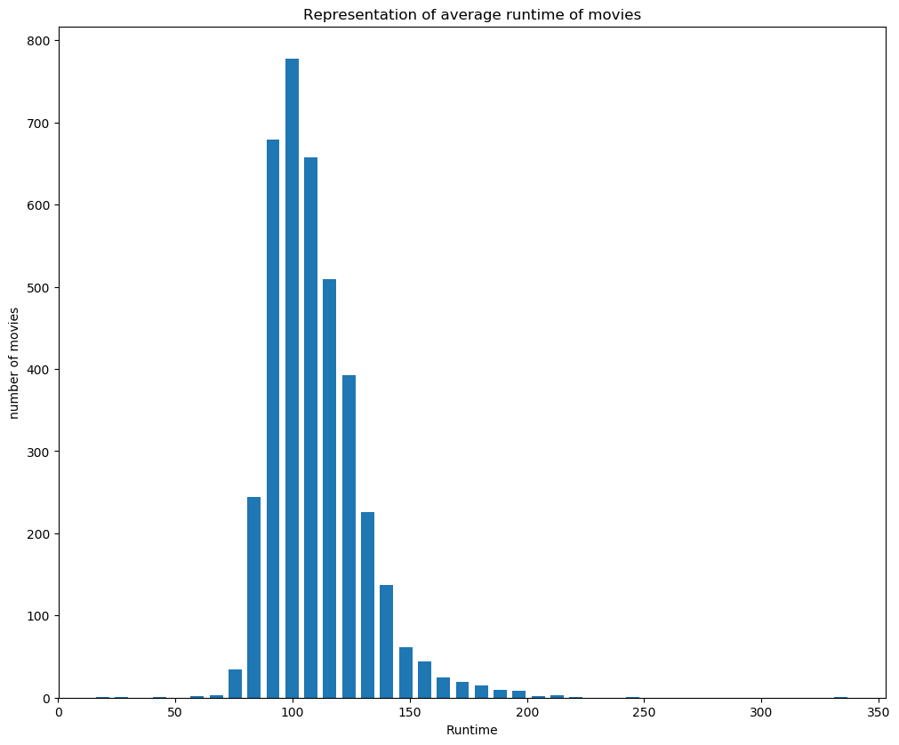

```python
plt.figure(figsize = (12,10), dpi = 100)
plt.title('Representation of average runtime of movies')
plt.hist(tmdb_data['runtime'], bins = 40, rwidth = 0.7)
plt.xlabel('Runtime')
plt.ylabel('number of movies')
plt.show()
```

### Research Question 5) What is the average budget of the movies?

```python
average('budget')
```

```
37203696.954852104
```

### Research Question 6) What is the average revenue of the movies?

```python
average('revenue')
```

```
107686616.09807992
```

##### How the budget and revenue changed with TIME?

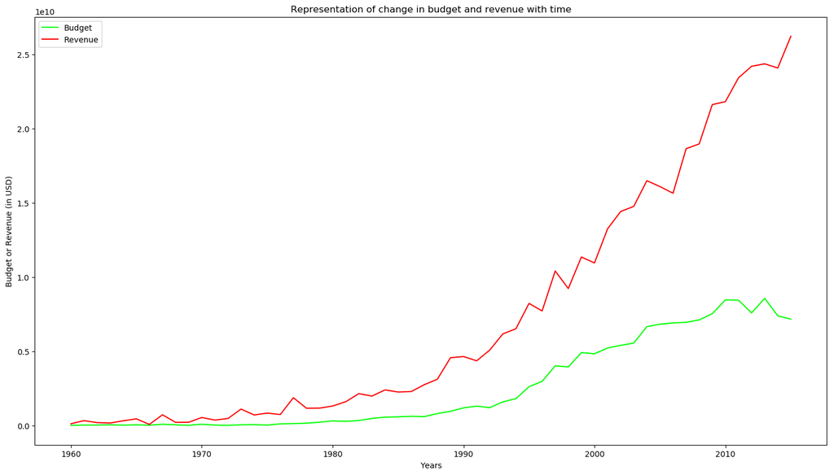

```python
Budget = tmdb_data.groupby('release_year')['budget'].sum()
Revenue = tmdb_data.groupby('release_year')['revenue'].sum()
plt.figure(figsize = (18,10), dpi = 100)
plt.title('Representation of change in budget and revenue with time')
plt.plot(Budget, color = '#00FF00', label = "Budget")
plt.plot(Revenue, color = '#FF0000', label = "Revenue")
plt.legend(loc = 'upper left')
plt.xlabel('Years')
plt.ylabel('Budget or Revenue (in USD)')
plt.show()
```

We can see that budget(green) and revenue(red) made a rapid growth from the year 1990 and increased till the year 2010. At the start, the profit seems to be negligible whereas in the end profit is significant.

### Research Question 7) Who are the most successful casts in the data set?

```python
successful_movies = tmdb_data[tmdb_data['Profit'] >= 40000000]
def success(column):
    data_list = successful_movies[column].str.cat(sep = '|')
    data_list = pd.Series(data_list.split('|'))
    counter = data_list.value_counts(ascending = False)
    return counter

counter = success('cast')
count = counter.head(10)
count
```

```
Tom Cruise            27
Tom Hanks             26
Brad Pitt             25
Cameron Diaz          22
Robert De Niro        21
Bruce Willis          21
Sylvester Stallone    21
Jim Carrey            20
Matt Damon            20
Denzel Washington     20
dtype: int64
```

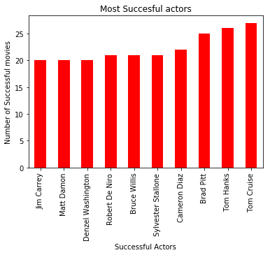

```python
count.sort_values(ascending = True, inplace = True)
plt.title('Most Succesful actors')
br = count.plot.bar(color = '#FF0000', fontsize = 10)
br.figure.set_size_inches(6,4)
plt.xlabel('Successful Actors')
plt.ylabel('Number of Successful movies')
plt.show()
```

### Research Question 8) What are the most successful genres in the data set?

```python
gen = success('genres')
genres = gen.head(10)
genres
```

```
Drama              554
Comedy             542
Action             505
Thriller           454
Adventure          402
Romance            244
Family             242
Crime              227
Science Fiction    219
Fantasy            212
dtype: int64
```

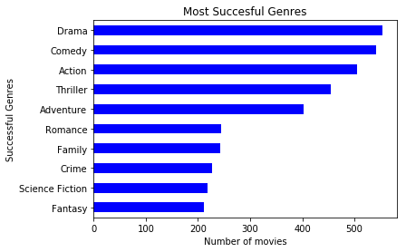

```python
genres.sort_values(ascending = True, inplace = True)
plt.title('Most Succesful Genres')

br = genres.plot.barh(color = '#0000FF', fontsize = 10)
br.figure.set_size_inches(6,4)
plt.ylabel('Successful Genres')
plt.xlabel('Number of movies')
plt.show()
```

## Conclusions

> **Tip**: Finally, summarize your findings and the results that have been performed. Make sure that you are clear with regards to the limitations of your exploration. If you haven't done any statistical tests, do not imply any statistical conclusions. And make sure you avoid implying causation from correlation!

> **Tip**: Once you are satisfied with your work, you should save a copy of the report in HTML or PDF form via the **File** > **Download as** submenu. Before exporting your report, check over it to make sure that the flow of the report is complete. You should probably remove all of the "Tip" quotes like this one so that the presentation is as tidy as possible. Congratulations!

### Data Analysis of tmdb data set includes several factors and outputs are helpful information for any film-maker.

I have used my algorithm to compute the questions listed for this data analysis. This analysis also has some graphical representations of the outcomes for better understanding.

The probabilities can differ and on the basis of the above outputs, I am predicting the favourable conditions for a successful movie.

The currency was not mentioned in the data list, so I have taken currency as USD because I assume that dataset is all about US Movies and every information is related to US.

##### Limitations:

1) Currency to the budget is not mentioned, we are predicting that our dataset is in USD. Whereas, dataset might contain some movies with budget in different currencies. 2) We donot believe that production companies influence the box office collection, which can be a factor but not necessarily. 3) If any movie is not having values in their budget or revenue column is deleted. We believe that revenue is an essential information and without that investigation can be biased. 4) Above outputs might not be an exact key to a block-buster creation, but there are compelling reasons that it might become a hit.